# IE582-Homework4

Hazal Hasret Yurdakul

19 December 2018

**Dataset 1: Mobil Price Range Prediction**

**Classification Problem**

Data includes mobile phone features such as battery power,being blue or not,ram,wifi and etc. to predict price range. There are 4 categories which are 0,1,2 and 3. 0 is the cheapest one and 3 is the most expensive category. We try to predict the classes of phone prices.

```r
setwd("C:/Users/hazalyurdakul/Desktop")
dataset = read.table("mobilprice.csv", sep = ";", header = TRUE)
names(dataset)
```

```
##  [1] "battery_power" "blue"          "clock_speed"   "dual_sim"
##  [5] "fc"            "four_g"        "int_memory"    "m_dep"
##  [9] "mobile_wt"     "n_cores"       "pc"            "px_height"
## [13] "px_width"      "ram"           "sc_h"          "sc_w"
## [17] "talk_time"     "three_g"       "touch_screen"  "wifi"
## [21] "price_range"
```

```r
str(dataset)
```

```
## 'data.frame':    2000 obs. of  21 variables:
##  $ battery_power: int  842 1021 563 615 1821 1859 1821 1954 1445 509 ...
##  $ blue         : int  0 1 1 1 1 0 0 0 1 1 ...
##  $ clock_speed  : num  2.2 0.5 0.5 2.5 1.2 0.5 1.7 0.5 0.5 0.6 ...
##  $ dual_sim     : int  0 1 1 0 0 1 0 1 0 1 ...
##  $ fc           : int  1 0 2 0 13 3 4 0 0 2 ...
##  $ four_g       : int  0 1 1 0 1 0 1 0 0 1 ...
##  $ int_memory   : int  7 53 41 10 44 22 10 24 53 9 ...
##  $ m_dep        : num  0.6 0.7 0.9 0.8 0.6 0.7 0.8 0.8 0.7 0.1 ...
##  $ mobile_wt    : int  188 136 145 131 141 164 139 187 174 93 ...
##  $ n_cores      : int  2 3 5 6 2 1 8 4 7 5 ...
##  $ pc           : int  2 6 6 9 14 7 10 0 14 15 ...
##  $ px_height    : int  20 905 1263 1216 1208 1004 381 512 386 1137 ...
##  $ px_width     : int  756 1988 1716 1786 1212 1654 1018 1149 836 1224 ...
##  $ ram          : int  2549 2631 2603 2769 1411 1067 3220 700 1099 513 ...
##  $ sc_h         : int  9 17 11 16 8 17 13 16 17 19 ...
##  $ sc_w         : int  7 3 2 8 2 1 8 3 1 10 ...
##  $ talk_time    : int  19 7 9 11 15 10 18 5 20 12 ...
##  $ three_g      : int  0 1 1 1 1 1 1 1 1 1 ...
##  $ touch_screen : int  0 1 1 0 1 0 0 1 0 0 ...
##  $ wifi         : int  1 0 0 0 0 0 1 1 0 0 ...
##  $ price_range  : int  1 2 2 2 1 1 3 0 0 0 ...
```

```r
dim(dataset)
```

```
## [1] 2000   21
```

We can generate train and test data using dataset and classes. 70% of the data is assigned as train data and the remaining instances are placed in test data.

```r
smp_size <- floor(0.7 * nrow(dataset))

## set the seed to make your partition reproducible
set.seed(123)
train_ind <- sample(seq_len(nrow(dataset)), size = smp_size)

mp.train <- dataset[train_ind, ]
mp.test <- dataset[-train_ind, ]

traindata = mp.train[, 2:ncol(mp.train) - 1]
testdata = mp.test[, 2:ncol(mp.test) - 1]

train.class = mp.train$price_range
test.class = mp.test$price_range
```

**1-Penalized Regression**

“glmnet” package is used for penalized lasso regression. Since it is lasso model, alpha is assigned as 1. Also, it is multiclass classification problem so that “multinomial” method will be appropriate method for family type. Also, 5 lamba values is tried with cross-validation. “cv.glmnet” performs cross-validation and select the best lambda value considering minimum cv-error. After choosing lambda value, model is created and trained. Using train data, accuracy is evaluated and compared with test data.

```r
# lasso penalty parameter
library(glmnet)

traindata = as.matrix(traindata)
train.class = as.factor(train.class)

cvfit = cv.glmnet(traindata, train.class, alpha = 1, family = "multinomial",
    nlambda = 5)
model = glmnet(traindata, train.class, alpha = 1, family = "multinomial",
    lambda = cvfit$lambda.min)

prediction = predict(model, traindata, type = "class")
confusionMatrix(factor(train.class), factor(prediction))
```

```
## Confusion Matrix and Statistics
##
##           Reference
## Prediction   0   1   2   3
##          0 354   1   0   0
##          1   2 354   0   0
##          2   0   3 333   6
##          3   0   0   7 340
##
## Overall Statistics
##
##                Accuracy : 0.9864
##                  95% CI : (0.9789, 0.9918)
##     No Information Rate : 0.2557
##     P-Value [Acc > NIR] : < 2.2e-16
##
##                   Kappa : 0.9819
##  Mcnemar's Test P-Value : NA
##
## Statistics by Class:
##
##                      Class: 0 Class: 1 Class: 2 Class: 3
## Sensitivity            0.9944   0.9888   0.9794   0.9827
## Specificity            0.9990   0.9981   0.9915   0.9934
## Pos Pred Value         0.9972   0.9944   0.9737   0.9798
## Neg Pred Value         0.9981   0.9962   0.9934   0.9943
## Prevalence             0.2543   0.2557   0.2429   0.2471
## Detection Rate         0.2529   0.2529   0.2379   0.2429
## Detection Prevalence   0.2536   0.2543   0.2443   0.2479
## Balanced Accuracy      0.9967   0.9935   0.9855   0.9880
```

```r
## test results
testdata = as.matrix(testdata)
prediction = predict(model, testdata, type = "class")
confusionMatrix(factor(test.class), factor(prediction))
```

```
## Confusion Matrix and Statistics
##
##           Reference
## Prediction   0   1   2   3
##          0 138   7   0   0
##          1   2 136   6   0
##          2   0   4 152   2
##          3   0   0   1 152
##
## Overall Statistics
##
##                Accuracy : 0.9633
##                  95% CI : (0.945, 0.9769)
##     No Information Rate : 0.265
##     P-Value [Acc > NIR] : < 2.2e-16
##
##                   Kappa : 0.9511
##  Mcnemar's Test P-Value : NA
##
## Statistics by Class:
##
##                      Class: 0 Class: 1 Class: 2 Class: 3
## Sensitivity            0.9857   0.9252   0.9560   0.9870
## Specificity            0.9848   0.9823   0.9864   0.9978
## Pos Pred Value         0.9517   0.9444   0.9620   0.9935
## Neg Pred Value         0.9956   0.9759   0.9842   0.9955
## Prevalence             0.2333   0.2450   0.2650   0.2567
## Detection Rate         0.2300   0.2267   0.2533   0.2533
## Detection Prevalence   0.2417   0.2400   0.2633   0.2550
## Balanced Accuracy      0.9852   0.9538   0.9712   0.9924
```

As you can see, lasso regression model performs really well. Accuracy of train data is 98.64% and accuracy of test data is found as 96.33%.

**2-Decision Tree**

Decision tree is constructed mainly using battery_power,px_height,px_width and ram variables. Also, corresponding tree is plotted for visualization. As you can see, decision tree achieves 85% of accuracy in train data and 80% of accuracy in test data. Penalized regression model performs better than decision tree.

```r
library(rpart)
library(rattle)
```

```r
library(rpart.plot)
library(caret)
library(data.table)

traindata = data.table(traindata)

set.seed(123)
trials <- expand.grid(minsplit_values = c(10, 15, 20, 25, 50),
    cp_values = c(0.005, 0.001, 0.01))

for (i in 1:nrow(trials)) {
    tree <- rpart(train.class ~ ., data = traindata, method = "class",
        control = rpart.control(cp = trials$cp_values[i], minsplit = trials$minsplit_values[i]))
    cv_error <- tree$cptable[which.min(tree$cptable[, "xerror"]),
        "xerror"]
    conf.mat = confusionMatrix(as.factor(train.class), predict(tree,
        type = "class"))
    print(paste0("cv_error=", cv_error, " accuracy=", unname(conf.mat$overall[1]),
        " cp=", trials$cp_values[i], " minsplit=", trials$minsplit_values[i]))
}
```

```
## [1] "cv_error=0.229885057471264 accuracy=0.875714285714286 cp=0.005 minsplit=10"
## [1] "cv_error=0.238505747126437 accuracy=0.875714285714286 cp=0.005 minsplit=15"
## [1] "cv_error=0.230842911877395 accuracy=0.875714285714286 cp=0.005 minsplit=20"
## [1] "cv_error=0.233716475095785 accuracy=0.875714285714286 cp=0.005 minsplit=25"
## [1] "cv_error=0.258620689655172 accuracy=0.854285714285714 cp=0.005 minsplit=50"
## [1] "cv_error=0.225095785440613 accuracy=0.943571428571429 cp=0.001 minsplit=10"
## [1] "cv_error=0.220306513409962 accuracy=0.922857142857143 cp=0.001 minsplit=15"
## [1] "cv_error=0.21360153256705 accuracy=0.910714285714286 cp=0.001 minsplit=20"
## [1] "cv_error=0.229885057471264 accuracy=0.904285714285714 cp=0.001 minsplit=25"
## [1] "cv_error=0.243295019157088 accuracy=0.862857142857143 cp=0.001 minsplit=50"
## [1] "cv_error=0.275862068965517 accuracy=0.85 cp=0.01 minsplit=10"
## [1] "cv_error=0.266283524904215 accuracy=0.85 cp=0.01 minsplit=15"
## [1] "cv_error=0.277777777777778 accuracy=0.85 cp=0.01 minsplit=20"
## [1] "cv_error=0.257662835249042 accuracy=0.85 cp=0.01 minsplit=25"
## [1] "cv_error=0.255747126436782 accuracy=0.85 cp=0.01 minsplit=50"
```

```r
tree <- rpart(train.class ~ ., data = traindata, method = "class",
    control = rpart.control(cp = 0.005, minsplit = 50))

printcp(tree)  #display cp table
```

```
##
## Classification tree:
## rpart(formula = train.class ~ ., data = traindata, method = "class",
##     control = rpart.control(cp = 0.005, minsplit = 50))
##
## Variables actually used in tree construction:
## [1] battery_power px_height     px_width      ram
##
## Root node error: 1044/1400 = 0.74571
##
## n= 1400
##
##          CP nsplit rel error  xerror     xstd
## 1 0.3314176      0   1.00000 1.04023 0.014949
## 2 0.2011494      1   0.66858 0.67050 0.017920
## 3 0.1570881      2   0.46743 0.47126 0.017110
## 4 0.0191571      3   0.31034 0.32854 0.015414
## 5 0.0134100      5   0.27203 0.29406 0.014829
## 6 0.0119732      7   0.24521 0.28161 0.014598
## 7 0.0100575      9   0.22126 0.27682 0.014506
## 8 0.0057471     11   0.20115 0.26820 0.014336
## 9 0.0050000     12   0.19540 0.26054 0.014180
```

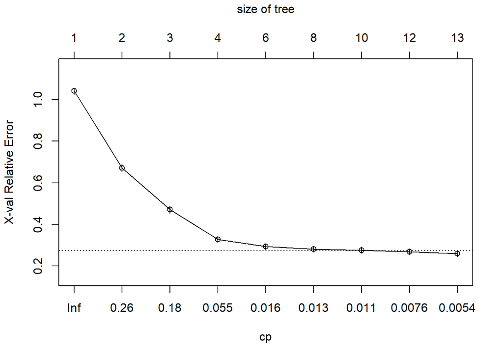

```r
plotcp(tree)
```

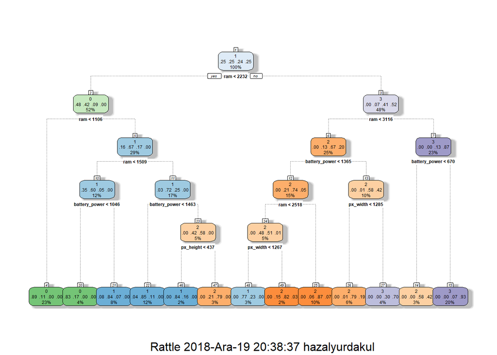

```r
fancyRpartPlot(tree, uniform = TRUE, tweak = 1.1)
```

```r
confusionMatrix(as.factor(train.class), predict(tree, traindata,
    type = "class"))
```

```
## Confusion Matrix and Statistics
##
##           Reference
## Prediction   0   1   2   3
##          0 339  16   0   0
##          1  46 286  24   0
##          2   0  39 266  37
##          3   0   0  42 305
##
## Overall Statistics
##
##                Accuracy : 0.8543
##                  95% CI : (0.8347, 0.8724)
##     No Information Rate : 0.275
##     P-Value [Acc > NIR] : < 2.2e-16
##
##                   Kappa : 0.8057
##  Mcnemar's Test P-Value : NA
##
## Statistics by Class:
##
##                      Class: 0 Class: 1 Class: 2 Class: 3
## Sensitivity            0.8805   0.8387   0.8012   0.8918
## Specificity            0.9842   0.9339   0.9288   0.9603
## Pos Pred Value         0.9549   0.8034   0.7778   0.8790
## Neg Pred Value         0.9560   0.9473   0.9376   0.9649
## Prevalence             0.2750   0.2436   0.2371   0.2443
## Detection Rate         0.2421   0.2043   0.1900   0.2179
## Detection Prevalence   0.2536   0.2543   0.2443   0.2479
## Balanced Accuracy      0.9324   0.8863   0.8650   0.9261
```

```r
## test results
testdata = data.table(testdata)
predictions = predict(tree, testdata, type = "class")
confusionMatrix(as.factor(test.class), predictions)
```

```
## Confusion Matrix and Statistics
##
##           Reference
## Prediction   0   1   2   3
##          0 130  15   0   0
##          1  17 108  19   0
##          2   0  20 109  29
##          3   0   0  19 134
##
## Overall Statistics
##
##                Accuracy : 0.8017
##                  95% CI : (0.7675, 0.8329)
##     No Information Rate : 0.2717
##     P-Value [Acc > NIR] : < 2.2e-16
##
##                   Kappa : 0.7355
##  Mcnemar's Test P-Value : NA
##
## Statistics by Class:
##
##                      Class: 0 Class: 1 Class: 2 Class: 3
## Sensitivity            0.8844   0.7552   0.7415   0.8221
## Specificity            0.9669   0.9212   0.8918   0.9565
## Pos Pred Value         0.8966   0.7500   0.6899   0.8758
## Neg Pred Value         0.9626   0.9232   0.9140   0.9351
## Prevalence             0.2450   0.2383   0.2450   0.2717
## Detection Rate         0.2167   0.1800   0.1817   0.2233
## Detection Prevalence   0.2417   0.2400   0.2633   0.2550
## Balanced Accuracy      0.9256   0.8382   0.8167   0.8893
```

**3-Support Vector Machine**

We try to set a support vector machine model and tune parameters for this purpose. Gamma and cost parameters are listed with different values.After tuning the parameters, the function chose the best cost and gamma values considering error and performance. Then, model is generated using suggested parameters.

“poly” kernel method is selected and 10-fold cross validation is done.The tuned parameters are found as cost=0.1 and gamma=0.5. Then, prediction is done for train and test data using those parameters.

As you can see, train data gives 100% accuracy which means that all observations are classified correctly. However, test data gives 77.5% of accuracy which is even smaller than accuracy of decision tree. We can say that support vector machine overfits train data and performs bad in test data.

```r
library(e1071)

# tuning
svm_tune_poly <- tune(svm, train.x = traindata, train.y = train.class,
    kernel = "poly", ranges = list(cost = 10^(-1:2), gamma = c(0.5,
        1, 2)))
summary(svm_tune_poly)
```

```
##
## Parameter tuning of 'svm':
##
## - sampling method: 10-fold cross validation
##
## - best parameters:
##  cost gamma
##   0.1   0.5
##
## - best performance: 0.2457143
##
## - Detailed performance results:
##     cost gamma     error dispersion
## 1    0.1   0.5 0.2457143 0.04557519
## 2    1.0   0.5 0.2457143 0.04557519
## 3   10.0   0.5 0.2457143 0.04557519
## 4  100.0   0.5 0.2457143 0.04557519
## 5    0.1   1.0 0.2457143 0.04557519
## 6    1.0   1.0 0.2457143 0.04557519
## 7   10.0   1.0 0.2457143 0.04557519
## 8  100.0   1.0 0.2457143 0.04557519
## 9    0.1   2.0 0.2457143 0.04557519
## 10   1.0   2.0 0.2457143 0.04557519
## 11  10.0   2.0 0.2457143 0.04557519
## 12 100.0   2.0 0.2457143 0.04557519
```

```r
svm_model_after_tune <- svm(train.class ~ ., data = traindata,
    kernel = "poly", cost = 0.1, gamma = 0.5)
summary(svm_model_after_tune)
```

```
##
## Call:
## svm(formula = train.class ~ ., data = traindata, kernel = "poly",
##     cost = 0.1, gamma = 0.5)
##
##
## Parameters:
##    SVM-Type:  C-classification
##  SVM-Kernel:  polynomial
##        cost:  0.1
##      degree:  3
##       gamma:  0.5
##      coef.0:  0
##
## Number of Support Vectors:  1105
##
##  ( 324 331 217 233 )
##
##
## Number of Classes:  4
##
## Levels:
##  0 1 2 3
```

```r
pred <- predict(svm_model_after_tune, traindata)
confusionMatrix(pred, train.class)
```

```
## Confusion Matrix and Statistics
##
##           Reference
## Prediction   0   1   2   3
##          0 355   0   0   0
##          1   0 356   0   0
##          2   0   0 342   0
##          3   0   0   0 347
##
## Overall Statistics
##
##                Accuracy : 1
##                  95% CI : (0.9974, 1)
##     No Information Rate : 0.2543
##     P-Value [Acc > NIR] : < 2.2e-16
##
##                   Kappa : 1
##  Mcnemar's Test P-Value : NA
##
## Statistics by Class:
##
##                      Class: 0 Class: 1 Class: 2 Class: 3
## Sensitivity            1.0000   1.0000   1.0000   1.0000
## Specificity            1.0000   1.0000   1.0000   1.0000
## Pos Pred Value         1.0000   1.0000   1.0000   1.0000
## Neg Pred Value         1.0000   1.0000   1.0000   1.0000
## Prevalence             0.2536   0.2543   0.2443   0.2479
## Detection Rate         0.2536   0.2543   0.2443   0.2479
## Detection Prevalence   0.2536   0.2543   0.2443   0.2479
## Balanced Accuracy      1.0000   1.0000   1.0000   1.0000
```

```r
pred <- predict(svm_model_after_tune, testdata)
confusionMatrix(pred, factor(test.class))
```

```
## Confusion Matrix and Statistics
##
##           Reference
## Prediction   0   1   2   3
##          0 121  12   0   0
##          1  23 102  18   0
##          2   1  29 111  22
##          3   0   1  29 131
##
## Overall Statistics
##
##                Accuracy : 0.775
##                  95% CI : (0.7394, 0.8078)
##     No Information Rate : 0.2633
##     P-Value [Acc > NIR] : < 2.2e-16
##
##                   Kappa : 0.6997
##  Mcnemar's Test P-Value : NA
##
## Statistics by Class:
##
##                      Class: 0 Class: 1 Class: 2 Class: 3
## Sensitivity            0.8345   0.7083   0.7025   0.8562
## Specificity            0.9736   0.9101   0.8824   0.9329
## Pos Pred Value         0.9098   0.7133   0.6810   0.8137
## Neg Pred Value         0.9486   0.9081   0.8924   0.9499
## Prevalence             0.2417   0.2400   0.2633   0.2550
## Detection Rate         0.2017   0.1700   0.1850   0.2183
## Detection Prevalence   0.2217   0.2383   0.2717   0.2683
## Balanced Accuracy      0.9041   0.8092   0.7924   0.8945
```

**4-Random Forest**

Random forest is performed to predict class information. Firstly, I generated a model with mtry=5 and examine the OOB error and class errors.After that, mtry parameter is tuned using “tuneRF” function. Different mtry levels are considered and the best mtry is selected using OOB(out-of-bag) error. In this case,mtry=8 gives the minimum OOB error according to the plot and model is generated using this value.

As you can see, prediction accuracy of train data 99.93% which is really good. Also, test data has 89.83% of accuracy which is second greatest one among 4 models.

```r
library(randomForest)
model1 <- randomForest(train.class ~ ., data = traindata, ntree = 500,
    mtry = 5, nodesize = 5)
model1
```

```
##
## Call:
##  randomForest(formula = train.class ~ ., data = traindata, ntree = 500,      mtry = 5, nodesize = 5)
##                Type of random forest: classification
##                      Number of trees: 500
## No. of variables tried at each split: 5
##
##         OOB estimate of  error rate: 10.86%
## Confusion matrix:
##     0   1   2   3 class.error
## 0 340  15   0   0  0.04225352
## 1  23 311  22   0  0.12640449
## 2   0  44 274  24  0.19883041
## 3   0   0  24 323  0.06916427
```

```r
# Execute the tuning process
set.seed(123)
res <- tuneRF(x = traindata, y = train.class, mtryStart = 1,
    ntreeTry = 500, stepFactor = 2, improve = 0.01)
```

```
## mtry = 1  OOB error = 31.14%
## Searching left ...
## Searching right ...
## mtry = 2     OOB error = 16.5%
## 0.4701835 0.01
## mtry = 4     OOB error = 11.57%
## 0.2987013 0.01
## mtry = 8     OOB error = 10.57%
## 0.08641975 0.01
## mtry = 16    OOB error = 10.79%
## -0.02027027 0.01
```

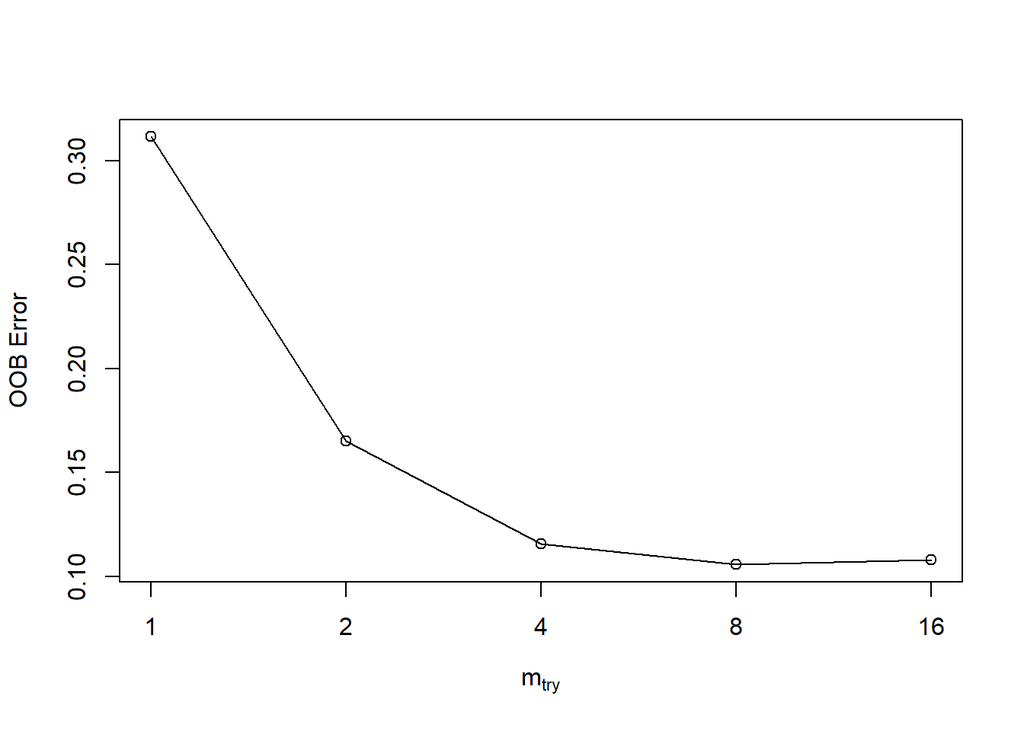

```r
# Look at results
print(res)
```

```
##        mtry  OOBError
## 1.OOB     1 0.3114286
## 2.OOB     2 0.1650000
## 4.OOB     4 0.1157143
## 8.OOB     8 0.1057143
## 16.OOB   16 0.1078571
```

```r
# Find the mtry value that minimizes OOB Error
mtry_opt <- res[, "mtry"][which.min(res[, "OOBError"])]
print(mtry_opt)
```

```
## 8.OOB
##     8
```

```r
model2 <- randomForest(train.class ~ ., data = traindata, ntree = 500,
    mtry = 8, nodesize = 5)
model2
```

```
##
## Call:
##  randomForest(formula = train.class ~ ., data = traindata, ntree = 500,      mtry = 8, nodesize = 5)
##                Type of random forest: classification
##                      Number of trees: 500
## No. of variables tried at each split: 8
##
##         OOB estimate of  error rate: 10.64%
## Confusion matrix:
##     0   1   2   3 class.error
## 0 339  16   0   0  0.04507042
## 1  23 310  23   0  0.12921348
## 2   0  35 281  26  0.17836257
## 3   0   0  26 321  0.07492795
```

```r
pred <- predict(model2, traindata)
confusionMatrix(pred, train.class)
```

```
## Confusion Matrix and Statistics
##
##           Reference
## Prediction   0   1   2   3
##          0 355   1   0   0
##          1   0 355   0   0
##          2   0   0 342   0
##          3   0   0   0 347
##
## Overall Statistics
##
##                Accuracy : 0.9993
##                  95% CI : (0.996, 1)
##     No Information Rate : 0.2543
##     P-Value [Acc > NIR] : < 2.2e-16
##
##                   Kappa : 0.999
##  Mcnemar's Test P-Value : NA
##
## Statistics by Class:
##
##                      Class: 0 Class: 1 Class: 2 Class: 3
## Sensitivity            1.0000   0.9972   1.0000   1.0000
## Specificity            0.9990   1.0000   1.0000   1.0000
## Pos Pred Value         0.9972   1.0000   1.0000   1.0000
## Neg Pred Value         1.0000   0.9990   1.0000   1.0000
## Prevalence             0.2536   0.2543   0.2443   0.2479
## Detection Rate         0.2536   0.2536   0.2443   0.2479
## Detection Prevalence   0.2543   0.2536   0.2443   0.2479
## Balanced Accuracy      0.9995   0.9986   1.0000   1.0000
```

```r
pred <- predict(model2, testdata)
confusionMatrix(pred, factor(test.class))
```

```
## Confusion Matrix and Statistics
##
##           Reference
## Prediction   0   1   2   3
##          0 132  11   0   0
##          1  13 125  12   0
##          2   0   8 135   6
##          3   0   0  11 147
##
## Overall Statistics
##
##                Accuracy : 0.8983
##                  95% CI : (0.8713, 0.9213)
##     No Information Rate : 0.2633
##     P-Value [Acc > NIR] : < 2.2e-16
##
##                   Kappa : 0.8644
##  Mcnemar's Test P-Value : NA
##
## Statistics by Class:
##
##                      Class: 0 Class: 1 Class: 2 Class: 3
## Sensitivity            0.9103   0.8681   0.8544   0.9608
## Specificity            0.9758   0.9452   0.9683   0.9754
## Pos Pred Value         0.9231   0.8333   0.9060   0.9304
## Neg Pred Value         0.9716   0.9578   0.9490   0.9864
## Prevalence             0.2417   0.2400   0.2633   0.2550
## Detection Rate         0.2200   0.2083   0.2250   0.2450
## Detection Prevalence   0.2383   0.2500   0.2483   0.2633
## Balanced Accuracy      0.9431   0.9066   0.9114   0.9681
```

**5-Gradient Boosting Machine**

Lastly, gradient boosting machine algorithm is used to predict classes. Grid search which iterates over every combination of hyperparameter is performed to assess which combination tends to perform well.Number of trees,learning rates and tree depth paramters are tuned for this purpose. While trying every combination, cross validation and train error are considered to choose the best parameters.

As you can see 850 trees are used after 1000 iterations. A gradient boosted model with multinomial loss is plotted to observe best cross-validation iteration which was 850.AS you can see, prediction accuracy of train data 100% which is really good. Also, test data has 89.33% of accuracy. We can say that, gbm model also performs well.

```r
library(gbm)
library(data.table)
library(caret)
library(dplyr)
# create hyperparameter grid
hyper_grid <- expand.grid(n.trees = c(1000, 5000), shrinkage = c(0.1,
    0.3), interaction.depth = c(1, 5))

optimal_trees = rep(NA, nrow(hyper_grid))  # a place to dump results
min_train_error = rep(NA, nrow(hyper_grid))
min_cv_error = rep(NA, nrow(hyper_grid))  # a place to dump results
# total number of combinations

traindata = data.table(traindata)

# grid search
for (i in 1:nrow(hyper_grid)) {
    # train model
    gbm.tune <- gbm(train.class ~ ., distribution = "multinomial",
        data = traindata, n.trees = hyper_grid$n.trees[i], interaction.depth = hyper_grid$interaction.depth[i],
        shrinkage = hyper_grid$shrinkage[i], cv.folds = 10, n.minobsinnode = 10)

    # add min training error and trees to grid
    optimal_trees[i] <- which.min(gbm.tune$cv.error)
    min_train_error[i] <- sqrt(min(gbm.tune$train.error))
    min_cv_error[i] <- sqrt(min(gbm.tune$cv.error))
}


cbind(hyper_grid, optimal_trees, min_train_error, min_cv_error) %>%
    dplyr::arrange(min_cv_error) %>% head(10)
```

```
##   n.trees shrinkage interaction.depth optimal_trees min_train_error
## 1    1000       0.1                 5           214    9.119839e-04
## 2    5000       0.1                 1           950    8.007156e-03
## 3    5000       0.1                 5           170    0.000000e+00
## 4    1000       0.1                 1           775    1.861718e-01
## 5    1000       0.3                 1           235    3.848807e-02
## 6    5000       0.3                 1           228    7.034772e-06
## 7    1000       0.3                 5            49    2.578344e-08
## 8    5000       0.3                 5            43             NaN
##   min_cv_error
## 1    0.4615033
## 2    0.4638979
## 3    0.4687088
## 4    0.4776997
## 5    0.4824582
## 6    0.4901355
## 7    0.5039397
## 8          NaN
```

```r
gbm.fit <- gbm(train.class ~ ., distribution = "multinomial",
    data = traindata, n.trees = 1000, interaction.depth = 1,
    shrinkage = 0.1, cv.folds = 10, n.minobsinnode = 10)

pred <- predict(gbm.fit, traindata, type = "response")
```

```
## Using 850 trees...
```

```r
gbm.fit
```

```
## gbm(formula = train.class ~ ., distribution = "multinomial",
##     data = traindata, n.trees = 1000, interaction.depth = 1,
##     n.minobsinnode = 10, shrinkage = 0.1, cv.folds = 10)
## A gradient boosted model with multinomial loss function.
## 1000 iterations were performed.
```

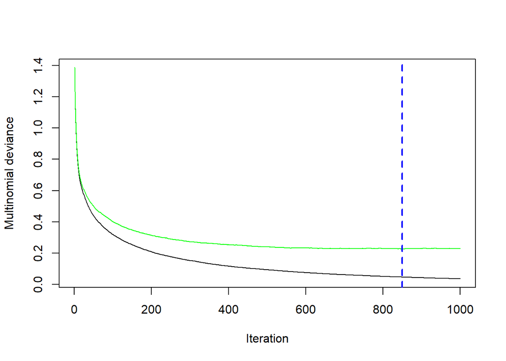

```
## The best cross-validation iteration was 850.
## There were 20 predictors of which 17 had non-zero influence.
```

```r
pred = pred[, , 1]

class = rep(NA, nrow(pred))
for (i in 1:nrow(pred)) {
    for (j in 1:ncol(pred)) {
        if (pred[i, j] == max(pred[i, ])) {
            class[i] = j - 1
        }
    }
}

confusionMatrix(factor(class), factor(train.class))
```

```
## Confusion Matrix and Statistics
##
##           Reference
## Prediction   0   1   2   3
##          0 355   0   0   0
##          1   0 356   0   0
##          2   0   0 342   0
##          3   0   0   0 347
##
## Overall Statistics
##
##                Accuracy : 1
##                  95% CI : (0.9974, 1)
##     No Information Rate : 0.2543
##     P-Value [Acc > NIR] : < 2.2e-16
##
##                   Kappa : 1
##  Mcnemar's Test P-Value : NA
##
## Statistics by Class:
##
##                      Class: 0 Class: 1 Class: 2 Class: 3
## Sensitivity            1.0000   1.0000   1.0000   1.0000
## Specificity            1.0000   1.0000   1.0000   1.0000
## Pos Pred Value         1.0000   1.0000   1.0000   1.0000
## Neg Pred Value         1.0000   1.0000   1.0000   1.0000
## Prevalence             0.2536   0.2543   0.2443   0.2479
## Detection Rate         0.2536   0.2543   0.2443   0.2479
## Detection Prevalence   0.2536   0.2543   0.2443   0.2479
## Balanced Accuracy      1.0000   1.0000   1.0000   1.0000
```

```r
pred <- predict(gbm.fit, testdata, type = "response")
```

```
## Using 850 trees...
```

```r
pred = pred[, , 1]

class = rep(NA, nrow(pred))
for (i in 1:nrow(pred)) {
    for (j in 1:ncol(pred)) {
        if (pred[i, j] == max(pred[i, ])) {
            class[i] = j - 1
        }
    }
}

confusionMatrix(factor(class), factor(test.class))
```

```
## Confusion Matrix and Statistics
##
##           Reference
## Prediction   0   1   2   3
##          0 132   3   1   0
##          1  13 129  17   0
##          2   0  12 128   6
##          3   0   0  12 147
##
## Overall Statistics
##
##                Accuracy : 0.8933
##                  95% CI : (0.8658, 0.9169)
##     No Information Rate : 0.2633
##     P-Value [Acc > NIR] : < 2.2e-16
##
##                   Kappa : 0.8578
##  Mcnemar's Test P-Value : NA
##
## Statistics by Class:
##
##                      Class: 0 Class: 1 Class: 2 Class: 3
## Sensitivity            0.9103   0.8958   0.8101   0.9608
## Specificity            0.9912   0.9342   0.9593   0.9732
## Pos Pred Value         0.9706   0.8113   0.8767   0.9245
## Neg Pred Value         0.9720   0.9660   0.9339   0.9864
## Prevalence             0.2417   0.2400   0.2633   0.2550
## Detection Rate         0.2200   0.2150   0.2133   0.2450
## Detection Prevalence   0.2267   0.2650   0.2433   0.2650
## Balanced Accuracy      0.9508   0.9150   0.8847   0.9670
```